# How to use *Astropy* to play with (FITS) tables: basic examples

Margherita Giustini $-$ Centro de Astrobiología (CAB), CSIC-INTA $-$ 21/february/2024

mgiustini@cab.inta-csic.es

## 0. Why using Astropy

I spent most of my life using software such as `fv` in order to manipulate flexible image transport system (FITS) files. I have always been quite slow, clumsy.

> `fv` *is the interactive FITS file viewer and editor, first developed at NASA Goddard in the 1990s as part of the [FTOOLS](https://heasarc.gsfc.nasa.gov/docs/software/ftools/ftools_menu.html).*

Life is much better since I am using **`astropy`**.

> The [Astropy Project](https://www.astropy.org/) **`astropy`** *is an open-source, community-developed core package for astronomy in Python, about 20-30 years younger than the FTOOLS*.

Why? Because I can quickly:

- rename columns;
- perform `numpy` operations on and between cells or columns;
- manually change cells values;
- visualize data with `matplotlib`;
- create new tables by filtering the original one using powerful masks;
- merge tables in smart ways;
- etc, etc

## 1. Open and explore a FITS table with `Astropy`

```python
import numpy as np
import matplotlib.pyplot as plt
from astropy.io import fits
from astropy.table import Table
```

```python
# The directory where the files are
workdir = "/Users/marghe/myDATA/myJupyter/"
```

Let's work with data of the galaxy RX J1301.9+2747, one of the six (+2) known sources of X-ray quasi-periodic eruptions (QPEs).

> *[QPEs](https://www.nature.com/articles/d41586-019-02652-y) are a new, peculiar cosmic signal associated with massive black holes in galactic nuclei, first [discovered at CAB](https://cab.inta-csic.es/wp-content/uploads/2019/11/np_2019_09_11_QPE_GSN_069_es.pdf) at the end of 2018/beginning of 2019 by Giovanni Miniutti, who was looking at the galaxy GSN 069 with [XMM-Newton](https://www.esa.int/Space_in_Member_States/Spain/Inesperadas_fulguraciones_periodicas_ayudan_a_comprender_la_acrecion_de_los_agujeros_negros).*

The data used in this tutorial are X-ray photons detected betwen $0.2-2$ keV by the EPIC-pn detector of the ESA satellite XMM-Newton in June 2022, while it has been pointing at RX J1301.9+2747 for about 33 hours.

> *XMM-Newton can actually detect photons up to 10 keV, but the signal of the QPE sources rapidly fades away at energies $> 2$ keV, thus at those energies the signal-to-noise ratio of our observations is negligible.*

The data have been processed using software and calibration files provided by the XMM-Newton Science Operation Center, and from them a light curve (time series: rate of arrival of X-ray counts in the detector as a function of time) has been created and stored in the FITS file `rxj_2022a_b250.lc`.

```python
# Open the fits file
hdu = fits.open(workdir + "rxj_2022a_b250.lc")
```

### 1.0 Check some basic information

```python
# Basic info about the FITS file
hdu.info()
```

```
Filename: /Users/marghe/myDATA/myJupyter/rxj_2022a_b250.lc
No.    Name      Ver    Type      Cards   Dimensions   Format
  0  PRIMARY       1 PrimaryHDU      17   ()
  1  RATE          1 BinTableHDU     84   472R x 6C   [D, E, E, E, E, E]
  2  SRC_GTIS      1 BinTableHDU     28   1R x 2C   [D, D]
  3  BKG_GTIS      1 BinTableHDU     28   1R x 2C   [D, D]
  4  REG00105      1 BinTableHDU     24   1R x 5C   [16A, E, E, E, B]
```

```python
# Check the information about the primary header
primary = hdu[0].header
print(primary)
```

```
SIMPLE  =                    T / file does conform to FITS standard             BITPIX  =                    8 / number of bits per data pixel                  NAXIS   =                    0 / number of data axes                            EXTEND  =                    T / FITS dataset may contain ex…
```

```python
# Access the data and header of the FITS table
data = hdu[1].data
header = hdu[1].header
```

```python
print(header)
```

```
XTENSION= 'BINTABLE'           / binary table extension                         BITPIX  =                    8 / 8-bit bytes                                    NAXIS   =                    2 / 2-dimensional binary table                     NAXIS1  =                   28 / width of table in bytes    …
```

```python
# Close the FITS file
hdu.close()
```

### 1.1 Explore the data with `astropy.table`

To create an Astropy table is this simple:

```python
# Convert the data into an Astropy table
table = Table(data)
```

...and visualizing the table is even simpler:

```python
table
```

*Table length=472*

| TIME float64 | RATE float32 | ERROR float32 | FRACEXP float32 | BACKV float32 | BACKE float32 |
| --- | --- | --- | --- | --- | --- |
| 771890254.45111 | 0.09794572 | 0.07963104 | 0.22294575 | 0.10399636 | 0.023254294 |
| 771890504.45111 | 0.26294088 | 0.1130824 | 0.17269927 | 0.09863355 | 0.024658388 |
| 771890754.45111 | 0.059243493 | 0.09703316 | 0.16665794 | 0.1463918 | 0.031210836 |
| 771891004.45111 | 0.25359952 | 0.09719804 | 0.21547452 | 0.08318027 | 0.020795068 |
| 771891254.45111 | 0.23729391 | 0.11482826 | 0.14901213 | 0.0857151 | 0.02474382 |
| 771891504.45111 | -0.003917122 | 0.080642544 | 0.16370325 | 0.12518853 | 0.029507218 |
| 771891754.45111 | 0.11992827 | 0.06925459 | 0.22190993 | 0.05185632 | 0.015635269 |
| 771892004.45111 | 0.13987741 | 0.0902826 | 0.2048184 | 0.10711702 | 0.025247723 |
| ... | ... | ... | ... | ... | ... |
| 772006254.45111 | 0.029954148 | 0.06515795 | 0.34947518 | 0.14862093 | 0.023499032 |
| 772006504.45111 | 0.08661991 | 0.07121896 | 0.31480068 | 0.13660479 | 0.020593945 |
| 772006754.45111 | -0.024352644 | 0.05769801 | 0.45468992 | 0.17710152 | 0.024100464 |
| 772007004.45111 | 0.084405266 | 0.08888331 | 0.28482673 | 0.21587935 | 0.027198242 |
| 772007254.45111 | 0.1405079 | 0.06557029 | 0.44765297 | 0.1330654 | 0.019836219 |
| 772007504.45111 | 0.13123837 | 0.09427237 | 0.27884364 | 0.21453379 | 0.02724582 |
| 772007754.45111 | 0.14592172 | 0.10038006 | 0.27579904 | 0.23571791 | 0.03043105 |
| 772008004.45111 | -0.045511466 | 0.09647064 | 0.2519104 | 0.27322435 | 0.04166632 |

If you want to print the table as it would appear in a console:

```python
print(table)
```

```
      TIME          RATE        ERROR     FRACEXP     BACKV       BACKE
--------------- ------------ ----------- ---------- ---------- -----------
771890254.45111   0.09794572  0.07963104 0.22294575 0.10399636 0.023254294
771890504.45111   0.26294088   0.1130824 0.17269927 0.09863355 0.024658388
771890754.45111  0.059243493  0.09703316 0.16665794  0.1463918 0.031210836
771891004.45111   0.25359952  0.09719804 0.21547452 0.08318027 0.020795068
771891254.45111   0.23729391  0.11482826 0.14901213  0.0857151  0.02474382
771891504.45111 -0.003917122 0.080642544 0.16370325 0.12518853 0.029507218
771891754.45111   0.11992827  0.06925459 0.22190993 0.05185632 0.015635269
771892004.45111   0.13987741   0.0902826  0.2048184 0.10711702 0.025247723
            ...          ...         ...        ...        ...         ...
772006004.45111   0.15228568  0.06466611 0.41206524 0.10600366 0.017667277
772006254.45111  0.029954148  0.06515795 0.34947518 0.14862093 0.023499032
772006504.45111   0.08661991  0.07121896 0.31480068 0.13660479 0.020593945
772006754.45111 -0.024352644  0.05769801 0.45468992 0.17710152 0.024100464
772007004.45111  0.084405266  0.08888331 0.28482673 0.21587935 0.027198242
772007254.45111    0.1405079  0.06557029 0.44765297  0.1330654 0.019836219
772007504.45111   0.13123837  0.09427237 0.27884364 0.21453379  0.02724582
772007754.45111   0.14592172  0.10038006 0.27579904 0.23571791  0.03043105
772008004.45111 -0.045511466  0.09647064  0.2519104 0.27322435  0.04166632
Length = 472 rows
```

If you want to print the full table:

```python
table.pprint(max_lines=-1, max_width=-1)
```

If you want to know the column names:

```python
table.colnames
```

```
['TIME', 'RATE', 'ERROR', 'FRACEXP', 'BACKV', 'BACKE']
```

If you want to access a specific column:

```python
table['RATE']
```

<Column name='RATE' dtype='float32' length=472>

| 0.09794572 |
| --- |
| 0.26294088 |
| 0.059243493 |
| 0.25359952 |
| 0.23729391 |
| -0.003917122 |
| 0.11992827 |
| 0.13987741 |
| 0.18154453 |
| 0.23755933 |
| ... |
| 0.06610958 |
| 0.15228568 |
| 0.029954148 |
| 0.08661991 |
| -0.024352644 |
| 0.084405266 |
| 0.1405079 |
| 0.13123837 |
| 0.14592172 |
| -0.045511466 |

If you want to access a specific row:

```python
table[7]
```

*Row index=7*

| TIME float64 | RATE float32 | ERROR float32 | FRACEXP float32 | BACKV float32 | BACKE float32 |
| --- | --- | --- | --- | --- | --- |
| 771892004.45111 | 0.13987741 | 0.0902826 | 0.2048184 | 0.10711702 | 0.025247723 |

If you want to access a specific row of a specific column:

```python
table['RATE'][7]
```

```
0.13987741
```

```python
table['RATE'][7]/2.
```

```
0.06993870437145233
```

```python
table['TIME'][471] - table['TIME'][0]
```

```
117750.0
```

### 1.2 Make a smaller table

This table has six columns, we can retain the first three in order to quickly explore the light curve:

```python
table = Table([table['TIME'], table['RATE'], table['ERROR']])
```

```python
table
```

*Table length=472*

| TIME float64 | RATE float32 | ERROR float32 |
| --- | --- | --- |
| 771890254.45111 | 0.09794572 | 0.07963104 |
| 771890504.45111 | 0.26294088 | 0.1130824 |
| 771890754.45111 | 0.059243493 | 0.09703316 |
| 771891004.45111 | 0.25359952 | 0.09719804 |
| 771891254.45111 | 0.23729391 | 0.11482826 |
| 771891504.45111 | -0.003917122 | 0.080642544 |
| 771891754.45111 | 0.11992827 | 0.06925459 |
| 771892004.45111 | 0.13987741 | 0.0902826 |
| ... | ... | ... |
| 772006254.45111 | 0.029954148 | 0.06515795 |
| 772006504.45111 | 0.08661991 | 0.07121896 |
| 772006754.45111 | -0.024352644 | 0.05769801 |
| 772007004.45111 | 0.084405266 | 0.08888331 |
| 772007254.45111 | 0.1405079 | 0.06557029 |
| 772007504.45111 | 0.13123837 | 0.09427237 |
| 772007754.45111 | 0.14592172 | 0.10038006 |
| 772008004.45111 | -0.045511466 | 0.09647064 |

It is easy to save the new FITS table:

```python
# table.write('output_table.fits', format='fits')
```

The table can be easily saved in any supported format, as e.g. a text file:

```python
# table.write('output_table.txt', format='ascii')
```

### 1.3 Using numpy or matplotlib with table content

```python
# we can print the light curve duration as the difference between the last and first time bins central values, plus 1 bin:
print('Light curve duration:', table['TIME'][471] - table['TIME'][0] + 250, 's')
```

```
Light curve duration: 118000.0 s
```

```python
lc_duration = table['TIME'][471] - table['TIME'][0] + 250
lc_duration
```

```
118000.0
```

```python
print('minimum light curve time (MRT):', table['TIME'][0], 's')
print('maximum light curve time (MRT):',table['TIME'][471], 's')
```

```
minimum light curve time (MRT): 771890254.45111 s
maximum light curve time (MRT): 772008004.45111 s
```

All the numpy functionalities can be applied to the table content, e.g.:

```python
print('maximum light curve count rate:', np.max(table['RATE']), 'count/s')
print('minimum light curve count rate:', np.min(table['RATE']), 'count/s')
```

```
maximum light curve count rate: 1.2294852 count/s
minimum light curve count rate: -0.045511466 count/s
```

All the matplotlib functionalities can be applied to the table content, e.g.:

```
No artists with labels found to put in legend.  Note that artists whose label start with an underscore are ignored when legend() is called with no argument.
```

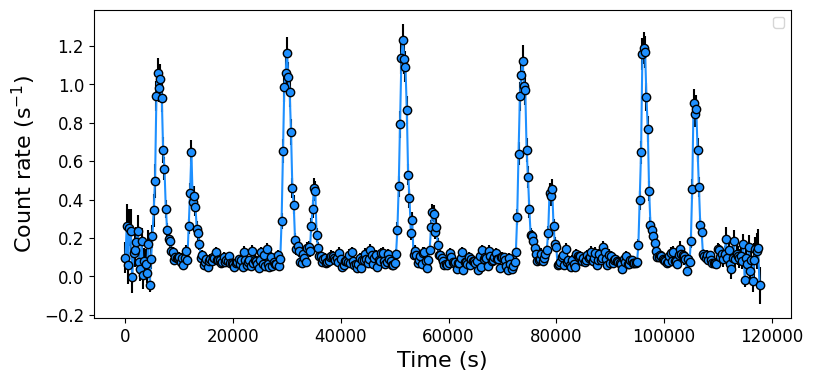

```python
# Plot the data
fig = plt.figure(figsize=(9, 4))
plt.errorbar(table['TIME']- table['TIME'][0], table['RATE'], yerr = table['ERROR'],
             c='dodgerblue', mfc='dodgerblue', mec='k', ecolor ='k', marker = 'o', alpha = 1)
plt.xlabel('Time (s)', fontsize=16)
plt.ylabel('Count rate (s$^{-1}$)', fontsize=16)
plt.legend(fontsize=10)
plt.xticks(fontsize=12)
plt.yticks(fontsize=12)
plt.show()
```

## 2. Playing tables with `Astropy`

### 2.0 Let's open the FITS table with the Bayesian analysis results

In this basic example we will load a FITS file containing tabular data of five XMM-Newton observations of RX J1301.9+2747.

The data are the results of the Bayesian comparison between the $0.2-2$ keV light curves of the five observations and a model comprising a constant plus Gaussian emission lines.

The constant represents the quiescent X-ray emission of the galaxy, while the Gaussians represent quasi-periodic eruptions (QPEs).

```python
# Open the FITS table I want to work with
hdul = fits.open(workdir + "qpe_table.fits")
data_qpe = hdul[1].data
cols_qpe = hdul[1].columns
```

```python
#table_qpe = Table(data_qpe)
```

```python
# Let's see what are the names of the columns of the table and what is the number of rows
print(cols_qpe)
print("Number of rows in the table:", len(data_qpe))
```

```
ColDefs(
    name = 'quie_mean'; format = 'D'
    name = 'quie_stdev'; format = 'D'
    name = 'quie_median'; format = 'D'
    name = 'quie_errlo'; format = 'D'
    name = 'quie_errup'; format = 'D'
    name = 'peak_mean'; format = 'D'
    name = 'peak_stdev'; format = 'D'
    name = 'peak_median'; format = 'D'
    name = 'peak_errlo'; format = 'D'
    name = 'peak_errup'; format = 'D'
    name = '$x0$_mean'; format = 'D'
    name = '$x0$_stdev'; format = 'D'
    name = '$x0$_median'; format = 'D'
    name = '$x0$_errlo'; format = 'D'
    name = '$x0$_errup'; format = 'D'
    name = 'sigma_mean'; format = 'D'
    name = 'sigma_stdev'; format = 'D'
    name = 'sigma_median'; format = 'D'
    name = 'sigma_errlo'; format = 'D'
    name = 'sigma_errup'; format = 'D'
)
Number of rows in the table: 32
```

### 2.1 Creating a new (smaller) table to work with

There are 32 QPEs in this table, and lots of data that we are not going to use for this brief tutorial.

Let's make a table retaining only the quantities that are of interest here: the QPE peak position in time, the QPE width, the QPE peak count rate, and the quiescence count rate; along with their 1$\sigma$ errors.

Each QPE has also an associated 'name', these are the non-consecutive integers, stored in the `qpe_index` array:

```python
# These are the individual names of the QPEs
qpe_index = np.array([1, 2, 3, 4, 6, 7, 8, 9, 10, 11, 12, 13, 14, 15, 16, 17, 18, 19, 20, 21, 22, 23, 24, 25, 26, 27, 28, 29, 30, 31, 32, 33])
```

```python
# Make arrays from the FITS file columns of interest; rename those with not-recommended characters

# QPE peak position in time and its error:
qpe_peak = data_qpe['$x0$_median']
qpe_peak_stdev = data_qpe['$x0$_stdev']

# standard deviation of the best-fitting Gaussian and its error:
sigma_median = data_qpe['sigma_median']
sigma_stdev = data_qpe['sigma_stdev']

# QPE (Gaussian) peak count rate and its error:
peak_median = data_qpe['peak_median']
peak_stdev = data_qpe['peak_stdev']

# quiescence (constant) count rate and its error:
quie_median = data_qpe['quie_median']
quie_stdev = data_qpe['quie_stdev']
```

```python
# Let's make a new table with the quantities of interest
qpe_table = Table([qpe_index, qpe_peak, qpe_peak_stdev, sigma_median, sigma_stdev, peak_median, peak_stdev, quie_median, quie_stdev],
    names=['qpe_name', 'qpe_peak', 'qpe_peak_stdev', 'sigma_median', 'sigma_stdev', 'peak_median', 'peak_stdev', 'quie_median', 'quie_stdev'])
```

```python
qpe_table
```

*Table length=32*

| qpe_name int64 | qpe_peak float64 | qpe_peak_stdev float64 | sigma_median float64 | sigma_stdev float64 | peak_median float64 | peak_stdev float64 | quie_median float64 | quie_stdev float64 |
| --- | --- | --- | --- | --- | --- | --- | --- | --- |
| 1 | 92884405.24024144 | 28.46081004419692 | 550.0078947651763 | 25.499255613010103 | 0.9655288015956912 | 0.05277658950372216 | 0.12383150068646556 | 0.0063354744200890475 |
| 2 | 675644602.386281 | 18.317295580382307 | 503.5347427156341 | 14.639093512487731 | 1.2995072188301964 | 0.051463083299228704 | 0.10068559416833751 | 0.004999810480514842 |
| 3 | 675664556.8454896 | 24.2316507146372 | 624.6753807594041 | 21.17148502093466 | 0.9814527600622186 | 0.04051107321290489 | 0.08570405673102444 | 0.004687426758252808 |
| 4 | 675678028.6373322 | 16.524080142449474 | 518.1026329589156 | 13.991398945657096 | 1.707035170938456 | 0.05820349847092003 | 0.11141499154584512 | 0.006462337011026419 |
| 6 | 710884694.3678955 | 38.59670748782425 | 472.6835286561633 | 33.355714777709494 | 0.4973064989026353 | 0.038058999679030384 | 0.10603245385470209 | 0.006123723727293371 |
| 7 | 710901693.7911484 | 22.639296607237473 | 654.8506715156316 | 20.47928331071895 | 1.1913176669858454 | 0.04419029792732303 | 0.08749133290576094 | 0.007296349008148614 |
| 8 | 710906306.5436723 | 37.534329346660606 | 421.21011232748623 | 36.248043197048816 | 0.37932004675376296 | 0.03458536930191016 | 0.09590695110776398 | 0.006638491298521474 |
| 9 | 710924566.8644441 | 23.980829542296718 | 593.2640873959161 | 21.855047012216296 | 1.0385517391891848 | 0.0462316968938604 | 0.09474568340078413 | 0.005255115492578207 |
| ... | ... | ... | ... | ... | ... | ... | ... | ... |
| 26 | 772071266.3038963 | 54.10362551345068 | 535.7561173039186 | 47.268953984929155 | 0.3856492687742654 | 0.033037936087034606 | 0.08690481930435337 | 0.008921019489802375 |
| 27 | 772089009.0161173 | 21.37307084128314 | 607.0490286667724 | 18.705845201734345 | 1.1615648051272789 | 0.04550560146055968 | 0.08227201628654661 | 0.004848620769905273 |
| 28 | 772094188.5897421 | 42.7531424066924 | 450.6560779322498 | 40.92031927925064 | 0.3217969100908067 | 0.031377691059641034 | 0.0802039032608393 | 0.0064751082383420165 |
| 29 | 772111108.2626563 | 22.433157718184184 | 635.6474897043859 | 18.243262164378 | 1.1642838446593884 | 0.04307814514656887 | 0.08285380208335574 | 0.00389298181303658 |
| 30 | 772126931.5187342 | 16.75098534773879 | 546.2391945170244 | 13.66484652697266 | 1.6123756904037547 | 0.05330836205677564 | 0.08399762959920454 | 0.0036471868226666177 |
| 31 | 772148836.6326252 | 22.649179164108205 | 615.4481112569598 | 19.380709609762174 | 1.1085053900130544 | 0.044295430559761505 | 0.08662788820218038 | 0.004070974658087088 |
| 32 | 772160747.1720746 | 20.7177727459938 | 534.7857827351993 | 16.85199883828077 | 1.138706396301349 | 0.04564405708657772 | 0.07964282312022963 | 0.004013902697582933 |
| 33 | 772178719.2786579 | 30.668057342714732 | 594.0481190844775 | 23.48186716998753 | 1.2683128623542603 | 0.056647049975153525 | 0.07276478144111219 | 0.0063005968529139195 |

```python
# Print the new table
print(qpe_table)

print("Number of columns:", len(qpe_table.columns))
print("Column names:", qpe_table.columns.keys())
```

```
qpe_name      qpe_peak       qpe_peak_stdev   ...     quie_median           quie_stdev
-------- ----------------- ------------------ ... ------------------- ---------------------
       1 92884405.24024144  28.46081004419692 ... 0.12383150068646556 0.0063354744200890475
       2  675644602.386281 18.317295580382307 ... 0.10068559416833751  0.004999810480514842
       3 675664556.8454896   24.2316507146372 ... 0.08570405673102444  0.004687426758252808
       4 675678028.6373322 16.524080142449474 ... 0.11141499154584512  0.006462337011026419
       6 710884694.3678955  38.59670748782425 ... 0.10603245385470209  0.006123723727293371
       7 710901693.7911484 22.639296607237473 ... 0.08749133290576094  0.007296349008148614
       8 710906306.5436723 37.534329346660606 ... 0.09590695110776398  0.006638491298521474
       9 710924566.8644441 23.980829542296718 ... 0.09474568340078413  0.005255115492578207
     ...               ...                ... ...                 ...                   ...
      25 772064169.9473902  70.31877053213964 ... 0.09932952749764688  0.010789120403907728
      26 772071266.3038963  54.10362551345068 ... 0.08690481930435337  0.008921019489802375
      27 772089009.0161173  21.37307084128314 ... 0.08227201628654661  0.004848620769905273
      28 772094188.5897421   42.7531424066924 ...  0.0802039032608393 0.0064751082383420165
      29 772111108.2626563 22.433157718184184 ... 0.08285380208335574   0.00389298181303658
      30 772126931.5187342  16.75098534773879 ... 0.08399762959920454 0.0036471868226666177
      31 772148836.6326252 22.649179164108205 ... 0.08662788820218038  0.004070974658087088
      32 772160747.1720746   20.7177727459938 ... 0.07964282312022963  0.004013902697582933
      33 772178719.2786579 30.668057342714732 ... 0.07276478144111219 0.0063005968529139195
Length = 32 rows
Number of columns: 9
Column names: odict_keys(['qpe_name', 'qpe_peak', 'qpe_peak_stdev', 'sigma_median', 'sigma_stdev', 'peak_median', 'peak_stdev', 'quie_median', 'quie_stdev'])
```

### 2.2 Round the quantities

```python
# Let's round the quantities to a few decimals
qpe_table['qpe_peak'] = qpe_table['qpe_peak'].round(2)
qpe_table['qpe_peak_stdev'] = qpe_table['qpe_peak_stdev'].round(2)
qpe_table['sigma_median'] = qpe_table['sigma_median'].round(2)
qpe_table['sigma_stdev'] = qpe_table['sigma_stdev'].round(3)
qpe_table['peak_median'] = qpe_table['peak_median'].round(2)
qpe_table['peak_stdev'] = qpe_table['peak_stdev'].round(3)
qpe_table['quie_median'] = qpe_table['quie_median'].round(4)
qpe_table['quie_stdev'] = qpe_table['quie_stdev'].round(4)
```

```python
print(qpe_table)
```

```
qpe_name   qpe_peak   qpe_peak_stdev sigma_median sigma_stdev peak_median peak_stdev quie_median quie_stdev
-------- ------------ -------------- ------------ ----------- ----------- ---------- ----------- ----------
       1  92884405.24          28.46       550.01      25.499        0.97      0.053      0.1238     0.0063
       2 675644602.39          18.32       503.53      14.639         1.3      0.051      0.1007      0.005
       3 675664556.85          24.23       624.68      21.171        0.98      0.041      0.0857     0.0047
       4 675678028.64          16.52        518.1      13.991        1.71      0.058      0.1114     0.0065
       6 710884694.37           38.6       472.68      33.356         0.5      0.038       0.106     0.0061
       7 710901693.79          22.64       654.85      20.479        1.19      0.044      0.0875     0.0073
       8 710906306.54          37.53       421.21      36.248        0.38      0.035      0.0959     0.0066
       9 710924566.86          23.98       593.26      21.855        1.04      0.046      0.0947     0.0053
     ...          ...            ...          ...         ...         ...        ...         ...        ...
      25 772064169.95          70.32       665.79      53.664        0.99      0.082      0.0993     0.0108
      26  772071266.3           54.1       535.76      47.269        0.39      0.033      0.0869     0.0089
      27 772089009.02          21.37       607.05      18.706        1.16      0.046      0.0823     0.0048
      28 772094188.59          42.75       450.66       40.92        0.32      0.031      0.0802     0.0065
      29 772111108.26          22.43       635.65      18.243        1.16      0.043      0.0829     0.0039
      30 772126931.52          16.75       546.24      13.665        1.61      0.053       0.084     0.0036
      31 772148836.63          22.65       615.45      19.381        1.11      0.044      0.0866     0.0041
      32 772160747.17          20.72       534.79      16.852        1.14      0.046      0.0796      0.004
      33 772178719.28          30.67       594.05      23.482        1.27      0.057      0.0728     0.0063
Length = 32 rows
```

### 2.3 Let's explore the table properties a bit

We can easily explore the data properties; for example we can plot the QPE position in time versus its peak count rate:

The time is in seconds elapsed since the beginning of the XMM-Newton mission (MRT, mission reference time), where $1\: yr \sim \pi\times10^7 s$.

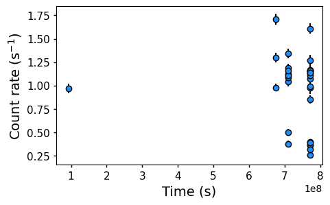

```python
# Plot of the peak position versus peak count rate
fig = plt.figure(figsize=(5, 3))
plt.errorbar(qpe_table['qpe_peak'], qpe_table['peak_median'], xerr=qpe_table['qpe_peak_stdev'], yerr=qpe_table['peak_stdev'],
             c='dodgerblue', mec='k', ecolor ='k', marker = 'o',linestyle='')
plt.xlabel('Time (s)', fontsize=14)
plt.ylabel('Count rate (s$^{-1}$)', fontsize=14)
plt.xticks(fontsize=11)
plt.yticks(fontsize=11)
plt.show()
```

The QPE peak times are clustered in four groups, corresponding to four different years of observations of RX J1301.9+2747:

Let's zoom into the June 2022A observation

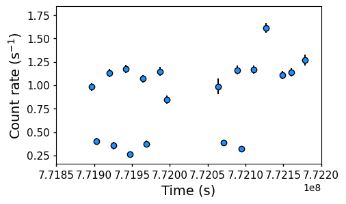

```python
# Let's zoom in at late times
fig = plt.figure(figsize=(5, 3))
plt.errorbar(qpe_table['qpe_peak'], qpe_table['peak_median'], xerr=qpe_table['qpe_peak_stdev'], yerr=qpe_table['peak_stdev'],
             c='dodgerblue', mec='k', ecolor ='k', marker = 'o',linestyle='')
plt.xlim(7.7185e8, 7.722e8)
plt.xlabel('Time (s)', fontsize=14)
plt.ylabel('Count rate (s$^{-1}$)', fontsize=14)
plt.xticks(fontsize=11)
plt.yticks(fontsize=11)
plt.show()
```

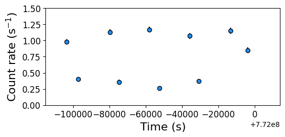

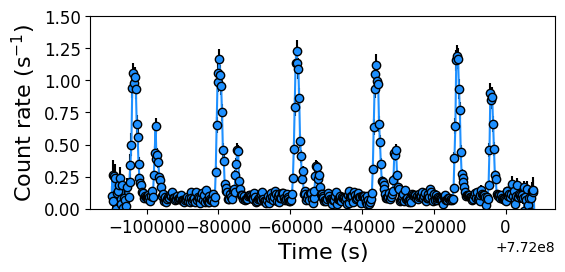

```python
# Let's zoom into the June 2022A observation
fig = plt.figure(figsize=(6, 2.5))
plt.errorbar(qpe_table['qpe_peak'], qpe_table['peak_median'], xerr=qpe_table['qpe_peak_stdev'], yerr=qpe_table['peak_stdev'],
             c='dodgerblue', mec='k', ecolor ='k', marker = 'o',linestyle='')
plt.xlim(7.71885e8, 7.72014e8)
plt.ylim(0., 1.5)
plt.xlabel('Time (s)', fontsize=16)
plt.ylabel('Count rate (s$^{-1}$)', fontsize=16)
plt.xticks(fontsize=12)
plt.yticks(fontsize=12)

fig = plt.figure(figsize=(6, 2.5))
plt.errorbar(table['TIME'], table['RATE'], yerr = table['ERROR'],
             c='dodgerblue', mfc='dodgerblue', mec='k', ecolor ='k', marker = 'o', alpha = 1)
plt.xlabel('Time (s)', fontsize=16)
plt.ylabel('Count rate (s$^{-1}$)', fontsize=16)
plt.ylim(0., 1.5)
plt.xticks(fontsize=12)
plt.yticks(fontsize=12)
plt.show()
```

### 2.4 Change column names

```python
qpe_table
```

*Table length=32*

| qpe_name int64 | qpe_peak float64 | qpe_peak_stdev float64 | sigma_median float64 | sigma_stdev float64 | peak_median float64 | peak_stdev float64 | quie_median float64 | quie_stdev float64 |
| --- | --- | --- | --- | --- | --- | --- | --- | --- |
| 1 | 92884405.24 | 28.46 | 550.01 | 25.499 | 0.97 | 0.053 | 0.1238 | 0.0063 |
| 2 | 675644602.39 | 18.32 | 503.53 | 14.639 | 1.3 | 0.051 | 0.1007 | 0.005 |
| 3 | 675664556.85 | 24.23 | 624.68 | 21.171 | 0.98 | 0.041 | 0.0857 | 0.0047 |
| 4 | 675678028.64 | 16.52 | 518.1 | 13.991 | 1.71 | 0.058 | 0.1114 | 0.0065 |
| 6 | 710884694.37 | 38.6 | 472.68 | 33.356 | 0.5 | 0.038 | 0.106 | 0.0061 |
| 7 | 710901693.79 | 22.64 | 654.85 | 20.479 | 1.19 | 0.044 | 0.0875 | 0.0073 |
| 8 | 710906306.54 | 37.53 | 421.21 | 36.248 | 0.38 | 0.035 | 0.0959 | 0.0066 |
| 9 | 710924566.86 | 23.98 | 593.26 | 21.855 | 1.04 | 0.046 | 0.0947 | 0.0053 |
| ... | ... | ... | ... | ... | ... | ... | ... | ... |
| 26 | 772071266.3 | 54.1 | 535.76 | 47.269 | 0.39 | 0.033 | 0.0869 | 0.0089 |
| 27 | 772089009.02 | 21.37 | 607.05 | 18.706 | 1.16 | 0.046 | 0.0823 | 0.0048 |
| 28 | 772094188.59 | 42.75 | 450.66 | 40.92 | 0.32 | 0.031 | 0.0802 | 0.0065 |
| 29 | 772111108.26 | 22.43 | 635.65 | 18.243 | 1.16 | 0.043 | 0.0829 | 0.0039 |
| 30 | 772126931.52 | 16.75 | 546.24 | 13.665 | 1.61 | 0.053 | 0.084 | 0.0036 |
| 31 | 772148836.63 | 22.65 | 615.45 | 19.381 | 1.11 | 0.044 | 0.0866 | 0.0041 |
| 32 | 772160747.17 | 20.72 | 534.79 | 16.852 | 1.14 | 0.046 | 0.0796 | 0.004 |
| 33 | 772178719.28 | 30.67 | 594.05 | 23.482 | 1.27 | 0.057 | 0.0728 | 0.0063 |

```python
qpe_table.rename_column('qpe_name', 'qpe_number')
```

```python
qpe_table
```

*Table length=32*

| qpe_number int64 | qpe_peak float64 | qpe_peak_stdev float64 | sigma_median float64 | sigma_stdev float64 | peak_median float64 | peak_stdev float64 | quie_median float64 | quie_stdev float64 |
| --- | --- | --- | --- | --- | --- | --- | --- | --- |
| 1 | 92884405.24 | 28.46 | 550.01 | 25.499 | 0.97 | 0.053 | 0.1238 | 0.0063 |
| 2 | 675644602.39 | 18.32 | 503.53 | 14.639 | 1.3 | 0.051 | 0.1007 | 0.005 |
| 3 | 675664556.85 | 24.23 | 624.68 | 21.171 | 0.98 | 0.041 | 0.0857 | 0.0047 |
| 4 | 675678028.64 | 16.52 | 518.1 | 13.991 | 1.71 | 0.058 | 0.1114 | 0.0065 |
| 6 | 710884694.37 | 38.6 | 472.68 | 33.356 | 0.5 | 0.038 | 0.106 | 0.0061 |
| 7 | 710901693.79 | 22.64 | 654.85 | 20.479 | 1.19 | 0.044 | 0.0875 | 0.0073 |
| 8 | 710906306.54 | 37.53 | 421.21 | 36.248 | 0.38 | 0.035 | 0.0959 | 0.0066 |
| 9 | 710924566.86 | 23.98 | 593.26 | 21.855 | 1.04 | 0.046 | 0.0947 | 0.0053 |
| ... | ... | ... | ... | ... | ... | ... | ... | ... |
| 26 | 772071266.3 | 54.1 | 535.76 | 47.269 | 0.39 | 0.033 | 0.0869 | 0.0089 |
| 27 | 772089009.02 | 21.37 | 607.05 | 18.706 | 1.16 | 0.046 | 0.0823 | 0.0048 |
| 28 | 772094188.59 | 42.75 | 450.66 | 40.92 | 0.32 | 0.031 | 0.0802 | 0.0065 |
| 29 | 772111108.26 | 22.43 | 635.65 | 18.243 | 1.16 | 0.043 | 0.0829 | 0.0039 |
| 30 | 772126931.52 | 16.75 | 546.24 | 13.665 | 1.61 | 0.053 | 0.084 | 0.0036 |
| 31 | 772148836.63 | 22.65 | 615.45 | 19.381 | 1.11 | 0.044 | 0.0866 | 0.0041 |
| 32 | 772160747.17 | 20.72 | 534.79 | 16.852 | 1.14 | 0.046 | 0.0796 | 0.004 |
| 33 | 772178719.28 | 30.67 | 594.05 | 23.482 | 1.27 | 0.057 | 0.0728 | 0.0063 |

### 2.5 Add a new column as a function of an existing one

Do we want to add a new column? Very easy: let's for example compute the QPE duration as $2\times$FWHM of the best-fitting Gaussian:

```python
qpe_table['qpe_duration'] = 2. * 2.3548 * qpe_table['sigma_median']

# Let's round also the duration:
qpe_table['qpe_duration'] = qpe_table['qpe_duration'].round(2)
```

```python
print(qpe_table)
```

```
qpe_number   qpe_peak   qpe_peak_stdev sigma_median ... peak_stdev quie_median quie_stdev qpe_duration
---------- ------------ -------------- ------------ ... ---------- ----------- ---------- ------------
         1  92884405.24          28.46       550.01 ...      0.053      0.1238     0.0063      2590.33
         2 675644602.39          18.32       503.53 ...      0.051      0.1007      0.005      2371.42
         3 675664556.85          24.23       624.68 ...      0.041      0.0857     0.0047      2941.99
         4 675678028.64          16.52        518.1 ...      0.058      0.1114     0.0065      2440.04
         6 710884694.37           38.6       472.68 ...      0.038       0.106     0.0061      2226.13
         7 710901693.79          22.64       654.85 ...      0.044      0.0875     0.0073      3084.08
         8 710906306.54          37.53       421.21 ...      0.035      0.0959     0.0066      1983.73
         9 710924566.86          23.98       593.26 ...      0.046      0.0947     0.0053      2794.02
       ...          ...            ...          ... ...        ...         ...        ...          ...
        25 772064169.95          70.32       665.79 ...      0.082      0.0993     0.0108       3135.6
        26  772071266.3           54.1       535.76 ...      0.033      0.0869     0.0089      2523.22
        27 772089009.02          21.37       607.05 ...      0.046      0.0823     0.0048      2858.96
        28 772094188.59          42.75       450.66 ...      0.031      0.0802     0.0065      2122.43
        29 772111108.26          22.43       635.65 ...      0.043      0.0829     0.0039      2993.66
        30 772126931.52          16.75       546.24 ...      0.053       0.084     0.0036      2572.57
        31 772148836.63          22.65       615.45 ...      0.044      0.0866     0.0041      2898.52
        32 772160747.17          20.72       534.79 ...      0.046      0.0796      0.004      2518.65
        33 772178719.28          30.67       594.05 ...      0.057      0.0728     0.0063      2797.74
Length = 32 rows
```

```python
qpe_table.show_in_notebook()
```

*Table length=32*

[output not shown]

We can perform mathematical operations column by column, e.g., let's compute the difference in time between consecutive QPEs:

Let's apply the `np.diff()` function to compute the differences between adjacent elements in the array of interest:

```python
# array containing the differences between each value of 'qpe_peak' and the previous value:
qpe_peak_diff = np.diff(qpe_table['qpe_peak'])
```

### 2.6 Apply numpy functions to the table

We can compute the difference in time between QPEs, using the information stored in `qpe_peak` and the `np.diff()` function.

> `np.diff()` is a NumPy function that computes the differences between adjacent elements in an array.

```python
# array containing the differences between each value of 'qpe_peak' and the previous value:
qpe_peak_diff = np.diff(qpe_table['qpe_peak'])
```

As there is no event before the first QPE, I need to add a NaN value in the first cell. For this reason I use the `np.concatenate()` function:

```python
# add a new column to the table representing the time elapsed between each 'qpe_peak' event and the previous one,
# and round it to two decimals.
qpe_table['time_before_QPE'] = np.concatenate(([np.nan], qpe_peak_diff))
qpe_table['time_before_QPE'] = qpe_table['time_before_QPE'].round(2)
```

```python
qpe_table
```

*Table length=32*

| qpe_number int64 | qpe_peak float64 | qpe_peak_stdev float64 | sigma_median float64 | sigma_stdev float64 | peak_median float64 | peak_stdev float64 | quie_median float64 | quie_stdev float64 | qpe_duration float64 | time_before_QPE float64 |
| --- | --- | --- | --- | --- | --- | --- | --- | --- | --- | --- |
| 1 | 92884405.24 | 28.46 | 550.01 | 25.499 | 0.97 | 0.053 | 0.1238 | 0.0063 | 2590.33 | nan |
| 2 | 675644602.39 | 18.32 | 503.53 | 14.639 | 1.3 | 0.051 | 0.1007 | 0.005 | 2371.42 | 582760197.15 |
| 3 | 675664556.85 | 24.23 | 624.68 | 21.171 | 0.98 | 0.041 | 0.0857 | 0.0047 | 2941.99 | 19954.46 |
| 4 | 675678028.64 | 16.52 | 518.1 | 13.991 | 1.71 | 0.058 | 0.1114 | 0.0065 | 2440.04 | 13471.79 |
| 6 | 710884694.37 | 38.6 | 472.68 | 33.356 | 0.5 | 0.038 | 0.106 | 0.0061 | 2226.13 | 35206665.73 |
| 7 | 710901693.79 | 22.64 | 654.85 | 20.479 | 1.19 | 0.044 | 0.0875 | 0.0073 | 3084.08 | 16999.42 |
| 8 | 710906306.54 | 37.53 | 421.21 | 36.248 | 0.38 | 0.035 | 0.0959 | 0.0066 | 1983.73 | 4612.75 |
| 9 | 710924566.86 | 23.98 | 593.26 | 21.855 | 1.04 | 0.046 | 0.0947 | 0.0053 | 2794.02 | 18260.32 |
| ... | ... | ... | ... | ... | ... | ... | ... | ... | ... | ... |
| 26 | 772071266.3 | 54.1 | 535.76 | 47.269 | 0.39 | 0.033 | 0.0869 | 0.0089 | 2523.22 | 7096.35 |
| 27 | 772089009.02 | 21.37 | 607.05 | 18.706 | 1.16 | 0.046 | 0.0823 | 0.0048 | 2858.96 | 17742.72 |
| 28 | 772094188.59 | 42.75 | 450.66 | 40.92 | 0.32 | 0.031 | 0.0802 | 0.0065 | 2122.43 | 5179.57 |
| 29 | 772111108.26 | 22.43 | 635.65 | 18.243 | 1.16 | 0.043 | 0.0829 | 0.0039 | 2993.66 | 16919.67 |
| 30 | 772126931.52 | 16.75 | 546.24 | 13.665 | 1.61 | 0.053 | 0.084 | 0.0036 | 2572.57 | 15823.26 |
| 31 | 772148836.63 | 22.65 | 615.45 | 19.381 | 1.11 | 0.044 | 0.0866 | 0.0041 | 2898.52 | 21905.11 |
| 32 | 772160747.17 | 20.72 | 534.79 | 16.852 | 1.14 | 0.046 | 0.0796 | 0.004 | 2518.65 | 11910.54 |
| 33 | 772178719.28 | 30.67 | 594.05 | 23.482 | 1.27 | 0.057 | 0.0728 | 0.0063 | 2797.74 | 17972.11 |

There are some inconsistencies in the table, as not all the QPEs belong to the same epoch of observation.

> Observations can be distinguished by their values of `qpe_peak` (QPE arrival time), or by their extremely large values of `time_before_QPE`, as the time between different observations is typically much longer than the time between QPEs.

In particular, the values of the first QPE of each observation need to be set to NaN as they are unknown:

```python
qpe_table['time_before_QPE'][1] = np.nan # Set the value of the time before the first QPE of the 2019 observation to NaN
qpe_table['time_before_QPE'][4] = np.nan # Set the value of the time before the first QPE of the 2020 observation to NaN
qpe_table['time_before_QPE'][13] = np.nan # Set the value of the time before the first QPE of the 2022a observation to NaN
qpe_table['time_before_QPE'][23] = np.nan # Set the value of the time before the first QPE of the 2022b observation to NaN

print(qpe_table)
```

```
qpe_number   qpe_peak   qpe_peak_stdev sigma_median ... quie_median quie_stdev qpe_duration time_before_QPE
---------- ------------ -------------- ------------ ... ----------- ---------- ------------ ---------------
         1  92884405.24          28.46       550.01 ...      0.1238     0.0063      2590.33             nan
         2 675644602.39          18.32       503.53 ...      0.1007      0.005      2371.42             nan
         3 675664556.85          24.23       624.68 ...      0.0857     0.0047      2941.99        19954.46
         4 675678028.64          16.52        518.1 ...      0.1114     0.0065      2440.04        13471.79
         6 710884694.37           38.6       472.68 ...       0.106     0.0061      2226.13             nan
         7 710901693.79          22.64       654.85 ...      0.0875     0.0073      3084.08        16999.42
         8 710906306.54          37.53       421.21 ...      0.0959     0.0066      1983.73         4612.75
         9 710924566.86          23.98       593.26 ...      0.0947     0.0053      2794.02        18260.32
       ...          ...            ...          ... ...         ...        ...          ...             ...
        25 772064169.95          70.32       665.79 ...      0.0993     0.0108       3135.6             nan
        26  772071266.3           54.1       535.76 ...      0.0869     0.0089      2523.22         7096.35
        27 772089009.02          21.37       607.05 ...      0.0823     0.0048      2858.96        17742.72
        28 772094188.59          42.75       450.66 ...      0.0802     0.0065      2122.43         5179.57
        29 772111108.26          22.43       635.65 ...      0.0829     0.0039      2993.66        16919.67
        30 772126931.52          16.75       546.24 ...       0.084     0.0036      2572.57        15823.26
        31 772148836.63          22.65       615.45 ...      0.0866     0.0041      2898.52        21905.11
        32 772160747.17          20.72       534.79 ...      0.0796      0.004      2518.65        11910.54
        33 772178719.28          30.67       594.05 ...      0.0728     0.0063      2797.74        17972.11
Length = 32 rows
```

### 2.7 Add a value manually

It can also be the case that for some observations the time of arrival of the QPE preceding the first one is known thanks to the presence of other X-ray instruments onboard XMM-Newton.

```python
qpe_table['time_before_QPE'][0] = 17857.0
qpe_table['time_before_QPE'][4] = 7596.0
```

```python
print(qpe_table)
```

```
qpe_number   qpe_peak   qpe_peak_stdev sigma_median ... quie_median quie_stdev qpe_duration time_before_QPE
---------- ------------ -------------- ------------ ... ----------- ---------- ------------ ---------------
         1  92884405.24          28.46       550.01 ...      0.1238     0.0063      2590.33         17857.0
         2 675644602.39          18.32       503.53 ...      0.1007      0.005      2371.42             nan
         3 675664556.85          24.23       624.68 ...      0.0857     0.0047      2941.99        19954.46
         4 675678028.64          16.52        518.1 ...      0.1114     0.0065      2440.04        13471.79
         6 710884694.37           38.6       472.68 ...       0.106     0.0061      2226.13          7596.0
         7 710901693.79          22.64       654.85 ...      0.0875     0.0073      3084.08        16999.42
         8 710906306.54          37.53       421.21 ...      0.0959     0.0066      1983.73         4612.75
         9 710924566.86          23.98       593.26 ...      0.0947     0.0053      2794.02        18260.32
       ...          ...            ...          ... ...         ...        ...          ...             ...
        25 772064169.95          70.32       665.79 ...      0.0993     0.0108       3135.6             nan
        26  772071266.3           54.1       535.76 ...      0.0869     0.0089      2523.22         7096.35
        27 772089009.02          21.37       607.05 ...      0.0823     0.0048      2858.96        17742.72
        28 772094188.59          42.75       450.66 ...      0.0802     0.0065      2122.43         5179.57
        29 772111108.26          22.43       635.65 ...      0.0829     0.0039      2993.66        16919.67
        30 772126931.52          16.75       546.24 ...       0.084     0.0036      2572.57        15823.26
        31 772148836.63          22.65       615.45 ...      0.0866     0.0041      2898.52        21905.11
        32 772160747.17          20.72       534.79 ...      0.0796      0.004      2518.65        11910.54
        33 772178719.28          30.67       594.05 ...      0.0728     0.0063      2797.74        17972.11
Length = 32 rows
```

### 2.8 We can quickly plot quantities

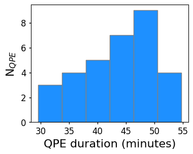

```python
fig = plt.figure(figsize=(4, 3))
plt.hist(qpe_table['qpe_duration']/60., bins=6, color='dodgerblue', edgecolor='grey', alpha=1.)
plt.xlabel('QPE duration (minutes)', fontsize=16)
plt.ylabel('N$_{QPE}$', fontsize=16)
plt.xticks(fontsize=12)
plt.yticks(fontsize=12)
plt.tick_params(axis='both', which='both', length=3, width=1)
plt.show()
```

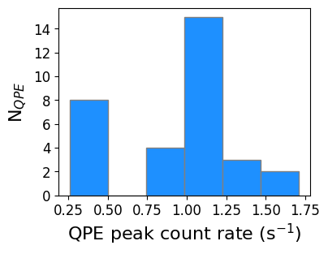

```python
fig = plt.figure(figsize=(4, 3))
plt.hist(qpe_table['peak_median'], bins=6, color='dodgerblue', edgecolor='grey', alpha=1.)
plt.xlabel('QPE peak count rate (s$^{-1}$)', fontsize=16)
plt.ylabel('N$_{QPE}$', fontsize=16)
plt.xticks(fontsize=12)
plt.yticks(fontsize=12)
plt.show()
```

## 3. Filtering tables

We can filter tables using masks.

Masks are expressions used against the original table, for example we can create a mask with a threshold in peak_median of $0.6$ counts/s, and splitting the table in one containing only QPEs below the treshold, one only those above:

```python
mask_high = qpe_table['peak_median'] > 0.6
qpe_table_strong = qpe_table[mask_high]

mask_low = qpe_table['peak_median'] < 0.6
qpe_table_weak = qpe_table[mask_low]
```

```python
print(qpe_table_weak)
```

```
qpe_number   qpe_peak   qpe_peak_stdev sigma_median ... quie_median quie_stdev qpe_duration time_before_QPE
---------- ------------ -------------- ------------ ... ----------- ---------- ------------ ---------------
         6 710884694.37           38.6       472.68 ...       0.106     0.0061      2226.13          7596.0
         8 710906306.54          37.53       421.21 ...      0.0959     0.0066      1983.73         4612.75
        16 771902786.25          44.71       572.48 ...       0.082      0.006      2696.15         6169.86
        18  771925260.7          38.21       375.96 ...      0.0976     0.0111      1770.62         4884.69
        20 771947541.01          55.38       562.06 ...      0.0512     0.0205      2647.08         5588.67
        22 771969291.93          34.06       421.73 ...      0.0812     0.0107      1986.18         5163.36
        26  772071266.3           54.1       535.76 ...      0.0869     0.0089      2523.22         7096.35
        28 772094188.59          42.75       450.66 ...      0.0802     0.0065      2122.43         5179.57
```

```python
print(qpe_table_strong)
```

```
qpe_number   qpe_peak   qpe_peak_stdev sigma_median ... quie_median quie_stdev qpe_duration time_before_QPE
---------- ------------ -------------- ------------ ... ----------- ---------- ------------ ---------------
         1  92884405.24          28.46       550.01 ...      0.1238     0.0063      2590.33         17857.0
         2 675644602.39          18.32       503.53 ...      0.1007      0.005      2371.42             nan
         3 675664556.85          24.23       624.68 ...      0.0857     0.0047      2941.99        19954.46
         4 675678028.64          16.52        518.1 ...      0.1114     0.0065      2440.04        13471.79
         7 710901693.79          22.64       654.85 ...      0.0875     0.0073      3084.08        16999.42
         9 710924566.86          23.98       593.26 ...      0.0947     0.0053      2794.02        18260.32
        10 710934983.57          20.38       433.53 ...      0.1049     0.0047      2041.75        10416.71
        11  710954379.3          23.63       565.87 ...      0.0991     0.0045      2665.02        19395.73
       ...          ...            ...          ... ...         ...        ...          ...             ...
        23  771986680.6          21.71       556.97 ...      0.0816     0.0041      2623.11        17388.67
        24 771996151.74          24.28       474.45 ...      0.0846     0.0055      2234.47         9471.14
        25 772064169.95          70.32       665.79 ...      0.0993     0.0108       3135.6             nan
        27 772089009.02          21.37       607.05 ...      0.0823     0.0048      2858.96        17742.72
        29 772111108.26          22.43       635.65 ...      0.0829     0.0039      2993.66        16919.67
        30 772126931.52          16.75       546.24 ...       0.084     0.0036      2572.57        15823.26
        31 772148836.63          22.65       615.45 ...      0.0866     0.0041      2898.52        21905.11
        32 772160747.17          20.72       534.79 ...      0.0796      0.004      2518.65        11910.54
        33 772178719.28          30.67       594.05 ...      0.0728     0.0063      2797.74        17972.11
Length = 24 rows
```

```python
qpe_table_strong.pprint(max_lines=-1, max_width=-1)
```

```
qpe_number   qpe_peak   qpe_peak_stdev sigma_median sigma_stdev peak_median peak_stdev quie_median quie_stdev qpe_duration time_before_QPE
---------- ------------ -------------- ------------ ----------- ----------- ---------- ----------- ---------- ------------ ---------------
         1  92884405.24          28.46       550.01      25.499        0.97      0.053      0.1238     0.0063      2590.33         17857.0
         2 675644602.39          18.32       503.53      14.639         1.3      0.051      0.1007      0.005      2371.42             nan
         3 675664556.85          24.23       624.68      21.171        0.98      0.041      0.0857     0.0047      2941.99        19954.46
         4 675678028.64          16.52        518.1      13.991        1.71      0.058      0.1114     0.0065      2440.04        13471.79
         7 710901693.79          22.64       654.85      20.479        1.19      0.044      0.0875     0.0073      3084.08        16999.42
         9 710924566.86          23.98       593.26      21.855        1.04      0.046      0.0947     0.0053      2794.02        18260.32
        10 710934983.57          20.38       433.53      17.527        1.09      0.055      0.1049     0.0047      2041.75        10416.71
        11  710954379.3          23.63       565.87      19.144        1.12      0.048      0.0991     0.0045      2665.02        19395.73
        12 710966182.46          21.73       514.91      17.708        1.11      0.048       0.102     0.0049      2425.02        11803.16
        13 710986317.22          22.87       614.67      17.847        1.16      0.044      0.1026      0.005      2894.85        20134.76
        14 711000240.99          19.15       548.92      15.806        1.34      0.052      0.1074     0.0035      2585.19        13923.77
        15 771896616.39          30.48        696.8      26.941        0.98       0.04      0.0955     0.0074      3281.65             nan
        17 771920376.01          22.94       616.26      18.651        1.13      0.044      0.0749     0.0061      2902.34        17589.76
        19 771941952.34          22.02       619.75      18.351        1.17      0.044      0.0845     0.0055      2918.77        16691.64
        21 771964128.57          25.33       649.38      19.594        1.07       0.04      0.0749     0.0048      3058.32        16587.56
        23  771986680.6          21.71       556.97      18.115        1.15      0.048      0.0816     0.0041      2623.11        17388.67
        24 771996151.74          24.28       474.45      20.074        0.85      0.044      0.0846     0.0055      2234.47         9471.14
        25 772064169.95          70.32       665.79      53.664        0.99      0.082      0.0993     0.0108       3135.6             nan
        27 772089009.02          21.37       607.05      18.706        1.16      0.046      0.0823     0.0048      2858.96        17742.72
        29 772111108.26          22.43       635.65      18.243        1.16      0.043      0.0829     0.0039      2993.66        16919.67
        30 772126931.52          16.75       546.24      13.665        1.61      0.053       0.084     0.0036      2572.57        15823.26
        31 772148836.63          22.65       615.45      19.381        1.11      0.044      0.0866     0.0041      2898.52        21905.11
        32 772160747.17          20.72       534.79      16.852        1.14      0.046      0.0796      0.004      2518.65        11910.54
        33 772178719.28          30.67       594.05      23.482        1.27      0.057      0.0728     0.0063      2797.74        17972.11
```

```python
qpes_to_keep = [1, 3, 7, 9, 11, 13, 15, 17, 19, 21, 23, 25, 27, 29, 31, 33]
column_name = 'qpe_number'

mask = np.isin(qpe_table_strong[column_name], qpes_to_keep)
qpe_table_strong_even = qpe_table_strong[mask]

print(qpe_table_strong_even)
```

```
qpe_number   qpe_peak   qpe_peak_stdev sigma_median ... quie_median quie_stdev qpe_duration time_before_QPE
---------- ------------ -------------- ------------ ... ----------- ---------- ------------ ---------------
         1  92884405.24          28.46       550.01 ...      0.1238     0.0063      2590.33         17857.0
         3 675664556.85          24.23       624.68 ...      0.0857     0.0047      2941.99        19954.46
         7 710901693.79          22.64       654.85 ...      0.0875     0.0073      3084.08        16999.42
         9 710924566.86          23.98       593.26 ...      0.0947     0.0053      2794.02        18260.32
        11  710954379.3          23.63       565.87 ...      0.0991     0.0045      2665.02        19395.73
        13 710986317.22          22.87       614.67 ...      0.1026      0.005      2894.85        20134.76
        15 771896616.39          30.48        696.8 ...      0.0955     0.0074      3281.65             nan
        17 771920376.01          22.94       616.26 ...      0.0749     0.0061      2902.34        17589.76
        19 771941952.34          22.02       619.75 ...      0.0845     0.0055      2918.77        16691.64
        21 771964128.57          25.33       649.38 ...      0.0749     0.0048      3058.32        16587.56
        23  771986680.6          21.71       556.97 ...      0.0816     0.0041      2623.11        17388.67
        25 772064169.95          70.32       665.79 ...      0.0993     0.0108       3135.6             nan
        27 772089009.02          21.37       607.05 ...      0.0823     0.0048      2858.96        17742.72
        29 772111108.26          22.43       635.65 ...      0.0829     0.0039      2993.66        16919.67
        31 772148836.63          22.65       615.45 ...      0.0866     0.0041      2898.52        21905.11
        33 772178719.28          30.67       594.05 ...      0.0728     0.0063      2797.74        17972.11
```

```python
mask = (qpe_table_strong_even['qpe_duration'] > 2800.) & (qpe_table_strong_even['qpe_duration'] < 3000.)
qpe_table_strong_even = qpe_table_strong_even[mask]
```

```python
qpe_table_strong_even
```

*Table length=7*

| qpe_number int64 | qpe_peak float64 | qpe_peak_stdev float64 | sigma_median float64 | sigma_stdev float64 | peak_median float64 | peak_stdev float64 | quie_median float64 | quie_stdev float64 | qpe_duration float64 | time_before_QPE float64 |
| --- | --- | --- | --- | --- | --- | --- | --- | --- | --- | --- |
| 3 | 675664556.85 | 24.23 | 624.68 | 21.171 | 0.98 | 0.041 | 0.0857 | 0.0047 | 2941.99 | 19954.46 |
| 13 | 710986317.22 | 22.87 | 614.67 | 17.847 | 1.16 | 0.044 | 0.1026 | 0.005 | 2894.85 | 20134.76 |
| 17 | 771920376.01 | 22.94 | 616.26 | 18.651 | 1.13 | 0.044 | 0.0749 | 0.0061 | 2902.34 | 17589.76 |
| 19 | 771941952.34 | 22.02 | 619.75 | 18.351 | 1.17 | 0.044 | 0.0845 | 0.0055 | 2918.77 | 16691.64 |
| 27 | 772089009.02 | 21.37 | 607.05 | 18.706 | 1.16 | 0.046 | 0.0823 | 0.0048 | 2858.96 | 17742.72 |
| 29 | 772111108.26 | 22.43 | 635.65 | 18.243 | 1.16 | 0.043 | 0.0829 | 0.0039 | 2993.66 | 16919.67 |
| 31 | 772148836.63 | 22.65 | 615.45 | 19.381 | 1.11 | 0.044 | 0.0866 | 0.0041 | 2898.52 | 21905.11 |

## 4. Merge tables quickly and smart

### Stack tables vertically: `vstack()`

Suppose that we want to merge two tables: very easy with `vstack()`

```python
print(qpe_table_weak)
```

```
qpe_number   qpe_peak   qpe_peak_stdev sigma_median ... quie_median quie_stdev qpe_duration time_before_QPE
---------- ------------ -------------- ------------ ... ----------- ---------- ------------ ---------------
         6 710884694.37           38.6       472.68 ...       0.106     0.0061      2226.13          7596.0
         8 710906306.54          37.53       421.21 ...      0.0959     0.0066      1983.73         4612.75
        16 771902786.25          44.71       572.48 ...       0.082      0.006      2696.15         6169.86
        18  771925260.7          38.21       375.96 ...      0.0976     0.0111      1770.62         4884.69
        20 771947541.01          55.38       562.06 ...      0.0512     0.0205      2647.08         5588.67
        22 771969291.93          34.06       421.73 ...      0.0812     0.0107      1986.18         5163.36
        26  772071266.3           54.1       535.76 ...      0.0869     0.0089      2523.22         7096.35
        28 772094188.59          42.75       450.66 ...      0.0802     0.0065      2122.43         5179.57
```

```python
print(qpe_table_strong_even)
```

```
qpe_number   qpe_peak   qpe_peak_stdev sigma_median ... quie_median quie_stdev qpe_duration time_before_QPE
---------- ------------ -------------- ------------ ... ----------- ---------- ------------ ---------------
         3 675664556.85          24.23       624.68 ...      0.0857     0.0047      2941.99        19954.46
        13 710986317.22          22.87       614.67 ...      0.1026      0.005      2894.85        20134.76
        17 771920376.01          22.94       616.26 ...      0.0749     0.0061      2902.34        17589.76
        19 771941952.34          22.02       619.75 ...      0.0845     0.0055      2918.77        16691.64
        27 772089009.02          21.37       607.05 ...      0.0823     0.0048      2858.96        17742.72
        29 772111108.26          22.43       635.65 ...      0.0829     0.0039      2993.66        16919.67
        31 772148836.63          22.65       615.45 ...      0.0866     0.0041      2898.52        21905.11
```

```python
from astropy.table import vstack
merged_table = vstack([qpe_table_weak, qpe_table_strong_even])
```

```python
print(merged_table)
```

```
qpe_number   qpe_peak   qpe_peak_stdev sigma_median ... quie_median quie_stdev qpe_duration time_before_QPE
---------- ------------ -------------- ------------ ... ----------- ---------- ------------ ---------------
         6 710884694.37           38.6       472.68 ...       0.106     0.0061      2226.13          7596.0
         8 710906306.54          37.53       421.21 ...      0.0959     0.0066      1983.73         4612.75
        16 771902786.25          44.71       572.48 ...       0.082      0.006      2696.15         6169.86
        18  771925260.7          38.21       375.96 ...      0.0976     0.0111      1770.62         4884.69
        20 771947541.01          55.38       562.06 ...      0.0512     0.0205      2647.08         5588.67
        22 771969291.93          34.06       421.73 ...      0.0812     0.0107      1986.18         5163.36
        26  772071266.3           54.1       535.76 ...      0.0869     0.0089      2523.22         7096.35
        28 772094188.59          42.75       450.66 ...      0.0802     0.0065      2122.43         5179.57
         3 675664556.85          24.23       624.68 ...      0.0857     0.0047      2941.99        19954.46
        13 710986317.22          22.87       614.67 ...      0.1026      0.005      2894.85        20134.76
        17 771920376.01          22.94       616.26 ...      0.0749     0.0061      2902.34        17589.76
        19 771941952.34          22.02       619.75 ...      0.0845     0.0055      2918.77        16691.64
        27 772089009.02          21.37       607.05 ...      0.0823     0.0048      2858.96        17742.72
        29 772111108.26          22.43       635.65 ...      0.0829     0.0039      2993.66        16919.67
        31 772148836.63          22.65       615.45 ...      0.0866     0.0041      2898.52        21905.11
```

```python
merged_table2 = vstack([qpe_table_strong_even,qpe_table_weak])
```

```python
print(merged_table2)
```

```
qpe_number   qpe_peak   qpe_peak_stdev sigma_median ... quie_median quie_stdev qpe_duration time_before_QPE
---------- ------------ -------------- ------------ ... ----------- ---------- ------------ ---------------
         3 675664556.85          24.23       624.68 ...      0.0857     0.0047      2941.99        19954.46
        13 710986317.22          22.87       614.67 ...      0.1026      0.005      2894.85        20134.76
        17 771920376.01          22.94       616.26 ...      0.0749     0.0061      2902.34        17589.76
        19 771941952.34          22.02       619.75 ...      0.0845     0.0055      2918.77        16691.64
        27 772089009.02          21.37       607.05 ...      0.0823     0.0048      2858.96        17742.72
        29 772111108.26          22.43       635.65 ...      0.0829     0.0039      2993.66        16919.67
        31 772148836.63          22.65       615.45 ...      0.0866     0.0041      2898.52        21905.11
         6 710884694.37           38.6       472.68 ...       0.106     0.0061      2226.13          7596.0
         8 710906306.54          37.53       421.21 ...      0.0959     0.0066      1983.73         4612.75
        16 771902786.25          44.71       572.48 ...       0.082      0.006      2696.15         6169.86
        18  771925260.7          38.21       375.96 ...      0.0976     0.0111      1770.62         4884.69
        20 771947541.01          55.38       562.06 ...      0.0512     0.0205      2647.08         5588.67
        22 771969291.93          34.06       421.73 ...      0.0812     0.0107      1986.18         5163.36
        26  772071266.3           54.1       535.76 ...      0.0869     0.0089      2523.22         7096.35
        28 772094188.59          42.75       450.66 ...      0.0802     0.0065      2122.43         5179.57
```

What happens if we want to merge two tables that do not share all the columns?

```python
qpe_tablez = Table([qpe_peak, qpe_peak_stdev,   peak_median, peak_stdev],
    names=['qpe_peak', 'qpe_peak_stdev', 'peak_median', 'peak_stdev'])
```

```python
qpe_tablez
```

*Table length=32*

| qpe_peak float64 | qpe_peak_stdev float64 | peak_median float64 | peak_stdev float64 |
| --- | --- | --- | --- |
| 92884405.24024144 | 28.46081004419692 | 0.9655288015956912 | 0.05277658950372216 |
| 675644602.386281 | 18.317295580382307 | 1.2995072188301964 | 0.051463083299228704 |
| 675664556.8454896 | 24.2316507146372 | 0.9814527600622186 | 0.04051107321290489 |
| 675678028.6373322 | 16.524080142449474 | 1.707035170938456 | 0.05820349847092003 |
| 710884694.3678955 | 38.59670748782425 | 0.4973064989026353 | 0.038058999679030384 |
| 710901693.7911484 | 22.639296607237473 | 1.1913176669858454 | 0.04419029792732303 |
| 710906306.5436723 | 37.534329346660606 | 0.37932004675376296 | 0.03458536930191016 |
| 710924566.8644441 | 23.980829542296718 | 1.0385517391891848 | 0.0462316968938604 |
| ... | ... | ... | ... |
| 772071266.3038963 | 54.10362551345068 | 0.3856492687742654 | 0.033037936087034606 |
| 772089009.0161173 | 21.37307084128314 | 1.1615648051272789 | 0.04550560146055968 |
| 772094188.5897421 | 42.7531424066924 | 0.3217969100908067 | 0.031377691059641034 |
| 772111108.2626563 | 22.433157718184184 | 1.1642838446593884 | 0.04307814514656887 |
| 772126931.5187342 | 16.75098534773879 | 1.6123756904037547 | 0.05330836205677564 |
| 772148836.6326252 | 22.649179164108205 | 1.1085053900130544 | 0.044295430559761505 |
| 772160747.1720746 | 20.7177727459938 | 1.138706396301349 | 0.04564405708657772 |
| 772178719.2786579 | 30.668057342714732 | 1.2683128623542603 | 0.056647049975153525 |

```python
merged_table3 = vstack([merged_table2, qpe_tablez]) # this is equivalent to join_type = outer
```

```python
merged_table3
```

*Table length=47*

| qpe_number int64 | qpe_peak float64 | qpe_peak_stdev float64 | sigma_median float64 | sigma_stdev float64 | peak_median float64 | peak_stdev float64 | quie_median float64 | quie_stdev float64 | qpe_duration float64 | time_before_QPE float64 |
| --- | --- | --- | --- | --- | --- | --- | --- | --- | --- | --- |
| 3 | 675664556.85 | 24.23 | 624.68 | 21.171 | 0.98 | 0.041 | 0.0857 | 0.0047 | 2941.99 | 19954.46 |
| 13 | 710986317.22 | 22.87 | 614.67 | 17.847 | 1.16 | 0.044 | 0.1026 | 0.005 | 2894.85 | 20134.76 |
| 17 | 771920376.01 | 22.94 | 616.26 | 18.651 | 1.13 | 0.044 | 0.0749 | 0.0061 | 2902.34 | 17589.76 |
| 19 | 771941952.34 | 22.02 | 619.75 | 18.351 | 1.17 | 0.044 | 0.0845 | 0.0055 | 2918.77 | 16691.64 |
| 27 | 772089009.02 | 21.37 | 607.05 | 18.706 | 1.16 | 0.046 | 0.0823 | 0.0048 | 2858.96 | 17742.72 |
| 29 | 772111108.26 | 22.43 | 635.65 | 18.243 | 1.16 | 0.043 | 0.0829 | 0.0039 | 2993.66 | 16919.67 |
| 31 | 772148836.63 | 22.65 | 615.45 | 19.381 | 1.11 | 0.044 | 0.0866 | 0.0041 | 2898.52 | 21905.11 |
| 6 | 710884694.37 | 38.6 | 472.68 | 33.356 | 0.5 | 0.038 | 0.106 | 0.0061 | 2226.13 | 7596.0 |
| ... | ... | ... | ... | ... | ... | ... | ... | ... | ... | ... |
| -- | 772071266.3038963 | 54.10362551345068 | -- | -- | 0.3856492687742654 | 0.033037936087034606 | -- | -- | -- | -- |
| -- | 772089009.0161173 | 21.37307084128314 | -- | -- | 1.1615648051272789 | 0.04550560146055968 | -- | -- | -- | -- |
| -- | 772094188.5897421 | 42.7531424066924 | -- | -- | 0.3217969100908067 | 0.031377691059641034 | -- | -- | -- | -- |
| -- | 772111108.2626563 | 22.433157718184184 | -- | -- | 1.1642838446593884 | 0.04307814514656887 | -- | -- | -- | -- |
| -- | 772126931.5187342 | 16.75098534773879 | -- | -- | 1.6123756904037547 | 0.05330836205677564 | -- | -- | -- | -- |
| -- | 772148836.6326252 | 22.649179164108205 | -- | -- | 1.1085053900130544 | 0.044295430559761505 | -- | -- | -- | -- |
| -- | 772160747.1720746 | 20.7177727459938 | -- | -- | 1.138706396301349 | 0.04564405708657772 | -- | -- | -- | -- |
| -- | 772178719.2786579 | 30.668057342714732 | -- | -- | 1.2683128623542603 | 0.056647049975153525 | -- | -- | -- | -- |

```python
merged_table4 = vstack([merged_table2, qpe_tablez], join_type='inner')
```

```python
merged_table4
```

*Table length=47*

| qpe_peak float64 | qpe_peak_stdev float64 | peak_median float64 | peak_stdev float64 |
| --- | --- | --- | --- |
| 675664556.85 | 24.23 | 0.98 | 0.041 |
| 710986317.22 | 22.87 | 1.16 | 0.044 |
| 771920376.01 | 22.94 | 1.13 | 0.044 |
| 771941952.34 | 22.02 | 1.17 | 0.044 |
| 772089009.02 | 21.37 | 1.16 | 0.046 |
| 772111108.26 | 22.43 | 1.16 | 0.043 |
| 772148836.63 | 22.65 | 1.11 | 0.044 |
| 710884694.37 | 38.6 | 0.5 | 0.038 |
| ... | ... | ... | ... |
| 772071266.3038963 | 54.10362551345068 | 0.3856492687742654 | 0.033037936087034606 |
| 772089009.0161173 | 21.37307084128314 | 1.1615648051272789 | 0.04550560146055968 |
| 772094188.5897421 | 42.7531424066924 | 0.3217969100908067 | 0.031377691059641034 |
| 772111108.2626563 | 22.433157718184184 | 1.1642838446593884 | 0.04307814514656887 |
| 772126931.5187342 | 16.75098534773879 | 1.6123756904037547 | 0.05330836205677564 |
| 772148836.6326252 | 22.649179164108205 | 1.1085053900130544 | 0.044295430559761505 |
| 772160747.1720746 | 20.7177727459938 | 1.138706396301349 | 0.04564405708657772 |
| 772178719.2786579 | 30.668057342714732 | 1.2683128623542603 | 0.056647049975153525 |

```python
merged_table5 = vstack([merged_table2, qpe_tablez], join_type='exact')
```

```
---------------------------------------------------------------------------
TableMergeError                           Traceback (most recent call last)
Cell In[154], line 1
----> 1 merged_table5 = vstack([merged_table2, qpe_tablez], join_type='exact')

File /usr/local/lib/python3.10/site-packages/astropy/table/operations.py:682, in vstack(tables, join_type, metadata_conflicts)
    679     return tables[0]  # no point in stacking a single table
    680 col_name_map = OrderedDict()
--> 682 out = _vstack(tables, join_type, col_name_map, metadata_conflicts)
    684 # Merge table metadata
    685 _merge_table_meta(out, tables, metadata_conflicts=metadata_conflicts)

File /usr/local/lib/python3.10/site-packages/astropy/table/operations.py:1446, in _vstack(arrays, join_type, col_name_map, metadata_conflicts)
   1444     for names in col_name_map.values():
   1445         if any(x is None for x in names):
-> 1446             raise TableMergeError(
   1447                 "Inconsistent columns in input arrays "
   1448                 "(use 'inner' or 'outer' join_type to "
   1449                 "allow non-matching columns)"
   1450             )
   1451     join_type = "outer"
   1453 # For an inner join, keep only columns where all input arrays have that column

TableMergeError: Inconsistent columns in input arrays (use 'inner' or 'outer' join_type to allow non-matching columns)
```

```python
merged_table5 = vstack([qpe_table_strong_even,qpe_table_weak], join_type='exact')
```

```python
merged_table5
```

*Table length=15*

| qpe_number int64 | qpe_peak float64 | qpe_peak_stdev float64 | sigma_median float64 | sigma_stdev float64 | peak_median float64 | peak_stdev float64 | quie_median float64 | quie_stdev float64 | qpe_duration float64 | time_before_QPE float64 |
| --- | --- | --- | --- | --- | --- | --- | --- | --- | --- | --- |
| 3 | 675664556.85 | 24.23 | 624.68 | 21.171 | 0.98 | 0.041 | 0.0857 | 0.0047 | 2941.99 | 19954.46 |
| 13 | 710986317.22 | 22.87 | 614.67 | 17.847 | 1.16 | 0.044 | 0.1026 | 0.005 | 2894.85 | 20134.76 |
| 17 | 771920376.01 | 22.94 | 616.26 | 18.651 | 1.13 | 0.044 | 0.0749 | 0.0061 | 2902.34 | 17589.76 |
| 19 | 771941952.34 | 22.02 | 619.75 | 18.351 | 1.17 | 0.044 | 0.0845 | 0.0055 | 2918.77 | 16691.64 |
| 27 | 772089009.02 | 21.37 | 607.05 | 18.706 | 1.16 | 0.046 | 0.0823 | 0.0048 | 2858.96 | 17742.72 |
| 29 | 772111108.26 | 22.43 | 635.65 | 18.243 | 1.16 | 0.043 | 0.0829 | 0.0039 | 2993.66 | 16919.67 |
| 31 | 772148836.63 | 22.65 | 615.45 | 19.381 | 1.11 | 0.044 | 0.0866 | 0.0041 | 2898.52 | 21905.11 |
| 6 | 710884694.37 | 38.6 | 472.68 | 33.356 | 0.5 | 0.038 | 0.106 | 0.0061 | 2226.13 | 7596.0 |
| 8 | 710906306.54 | 37.53 | 421.21 | 36.248 | 0.38 | 0.035 | 0.0959 | 0.0066 | 1983.73 | 4612.75 |
| 16 | 771902786.25 | 44.71 | 572.48 | 39.583 | 0.4 | 0.031 | 0.082 | 0.006 | 2696.15 | 6169.86 |
| 18 | 771925260.7 | 38.21 | 375.96 | 46.884 | 0.36 | 0.039 | 0.0976 | 0.0111 | 1770.62 | 4884.69 |
| 20 | 771947541.01 | 55.38 | 562.06 | 83.138 | 0.26 | 0.029 | 0.0512 | 0.0205 | 2647.08 | 5588.67 |
| 22 | 771969291.93 | 34.06 | 421.73 | 40.214 | 0.37 | 0.034 | 0.0812 | 0.0107 | 1986.18 | 5163.36 |
| 26 | 772071266.3 | 54.1 | 535.76 | 47.269 | 0.39 | 0.033 | 0.0869 | 0.0089 | 2523.22 | 7096.35 |
| 28 | 772094188.59 | 42.75 | 450.66 | 40.92 | 0.32 | 0.031 | 0.0802 | 0.0065 | 2122.43 | 5179.57 |